# A-5 Data Report

Nathan

5/18/2021

This is a data report regarding shootings that occurred across the United States in 2018.

## Summary Information

This summary information is analyzation of 2018 USA shooting that provide relevant information calculated from the data set. There were a total of 340 shootings that occurred in the USA in 2018. In these shootings, there were a tragic amount of 373 total lives lost in the year, with 17 deaths being the most to happen in one day. 30 injuries was the highest amount of injuries to occur in one day. The city which had the most impactful shooting (most deaths to happen) was Pompano Beach (Parkland).

## Summary Table

The table below is an aggregate summary of information from the 2018 shootings data. The table shows the top 10 states that had the most 2018 casualties in descending order, while also providing the total amount of injured people in that state (not in a particular order).

| State | Total Casualties | Total Injuries |
| --- | --- | --- |
| California | 50 | 136 |
| Florida | 48 | 132 |
| Pennsylvania | 35 | 63 |
| Texas | 29 | 62 |
| Illinois | 21 | 150 |
| Tennessee | 19 | 68 |
| Louisiana | 15 | 50 |
| North Carolina | 14 | 37 |
| Maryland | 13 | 31 |
| Ohio | 13 | 46 |

## Description of a Particular Incident

On February 14, 2018, one of the most deadly and tragic shootings occurred. A teen gunman used an AR-15 style semi-automatic rifle to open fire on his former high school located in Pompano Beach (Parkland). The gunman, Nikolas Cruz was found and arrested nearby in Coral Springs after murdering 17 people, and injuring 17. He impacted a total of 34 people with his weapon. Although Nikolas had no accomplices, he still caused tragic damage. [Link to article](https://www.nbcnews.com/news/us-news/police-respond-shooting-parkland-florida-high-school-n848101)

## Interactive Map

Below is an interactive map that is a data visualization to show the location of each shooting that occurred in 2018. The sizes of the markers indicate the impact of each shooting, the higher deaths/injuries mean the bigger the markers. This lets us easily compare which locations shooting were more or less severe.

[interactive chart not shown]

One insight revealed by this map is that we can see that the east side of the U.S. has far more shooting occurrences than the west cost. Another insight is that we can see which areas has more impacted people based on how big the markers are

## Plot of Choice

With the bar chart I’ve created below, I can answer the question, “Which month in 2018 had the highest number of occurred shootings?” The bar chart is organized by months in the x-axis, and the y-axis is the number of shootings that happened in that month across the U.S.. I chose to use this visual encoding because bar plots are best used to represent ordinal data, which is what this data is.

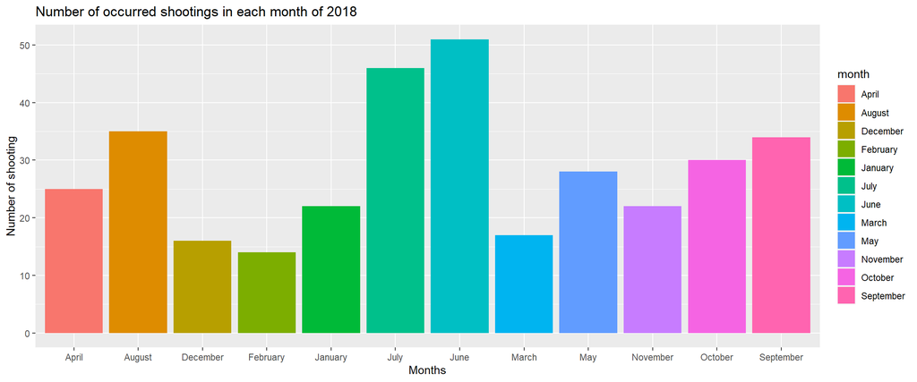

One insight gained from this chart is we can easily see which months had higher occurrences of shootings. Another insight gained is that it seems most shootings tend to happen in the middle of the year around summer time, as June, July, and August are the top 3 months for amount of shootings.